# MSR Final Assignment

Audrya Kerenhappukh | Cihan Acilov | Anuruddha Punam Kristhombuge

11/8/2021

## Data Preparation

Import data set and select only limited range

```r
RawDF <- read_excel("HAN_Stat & Math Foundation-Assignment _rel 02.xlsx",
                    range = "B11:H22")
print(RawDF)
```

| Students | 1 | 2 | 3 | 4 | 5 | 6 |
| --- | --- | --- | --- | --- | --- | --- |
| a | 3 | 9 | 9 | 3 | 8 | 9 |
| b | 8 | 8 | 7 | 4 | 8 | 8 |
| c | 9 | 10 | 9 | 9 | 6 | 10 |
| d | 4 | 7 | 4 | 2 | 7 | 9 |
| e | 7 | 9 | 8 | 4 | 7 | 9 |
| f | 10 | 7 | 4 | 3 | 4 | 8 |
| g | 5 | 9 | 8 | 5 | 7 | 10 |
| h | 6 | 9 | 5 | 4 | 6 | 10 |
| i | 4 | 8 | 6 | 4 | 4 | 10 |
| j | 7 | 7 | 5 | 1 | 4 | 9 |

[output cut: 1 more lines]

```r
NA
```

```r
CleanDF <- RawDF %>% gather(key=Courses, value=Grade, -Students)

#Example of dataset for a student
CleanDF %>% filter(Students=='a') %>% print()
```

| Students | Courses | Grade |
| --- | --- | --- |
| a | 1 | 3 |
| a | 2 | 9 |
| a | 3 | 9 |
| a | 4 | 3 |
| a | 5 | 8 |
| a | 6 | 9 |

```r
NA
```

## Data Understanding

### Table with Trend Graphics

Use Sparkline package to create a sparkline HTML table as following

```r
#Create HTML table for Histogram
course_histogram_data <- CleanDF %>%
  group_by(Courses) %>%
  summarise(
    Histogram = spk_chr(
      Grade, type ="bar",
      chartRangeMin = 100, chartRangeMax = max(Grade)
    )
  )

#Create HTML table for Sparkline
course_sparkline_data <- CleanDF %>%
  group_by(Courses) %>%
  summarise(
    Sparkline = spk_chr(
      Grade, type ="line",
      chartRangeMin = 100, chartRangeMax = max(Grade)
    )
  )

#Example of data frame:
head(course_histogram_data,2)
```

| Courses | Histogram |
| --- | --- |
| 1 | \n{"x":{"values":[3,8,9,4,7,10,5,6,4,7,10],"options":{"type":"bar","chartRangeMin":100,"chartRangeMax":10,"height":20,"width":60},"width":60,"height":20},"evals":[],"jsHooks":[]} |
| 2 | \n{"x":{"values":[9,8,10,7,9,7,9,9,8,7,7],"options":{"type":"bar","chartRangeMin":100,"chartRangeMax":10,"height":20,"width":60},"width":60,"height":20},"evals":[],"jsHooks":[]} |

Merge the sparkline/histogram table with the current dataset.

```r
#As dataset above are showing courses number as one column, we need to transpose the table so it becomes column names
trend.rows <- left_join(course_histogram_data, course_sparkline_data) %>% t() %>% as.data.frame()
#Promote the first row as headline
colnames(trend.rows) <- trend.rows[1,]
trend.rows = trend.rows[-1, ]


trend.rows <- tibble::rownames_to_column(trend.rows, "Students")

head(trend.rows, 2)
```

|  | Students | 1 | 2 | 3 | 4 | 5 | 6 |
| --- | --- | --- | --- | --- | --- | --- | --- |
| 1 | Histogram | \n{"x":{"values":[3,8,9,4,7,10,5,6,4,7,10],"options":{"type":"bar","chartRangeMin":100,"chartRangeMax":10,"height":20,"width":60},"width":60,"height":20},"evals":[],"jsHooks":[]} | \n{"x":{"values":[9,8,10,7,9,7,9,9,8,7,7],"options":{"type":"bar","chartRangeMin":100,"chartRangeMax":10,"height":20,"width":60},"width":60,"height":20},"evals":[],"jsHooks":[]} | \n{"x":{"values":[9,7,9,4,8,4,8,5,6,5,9],"options":{"type":"bar","chartRangeMin":100,"chartRangeMax":9,"height":20,"width":60},"width":60,"height":20},"evals":[],"jsHooks":[]} | \n{"x":{"values":[3,4,9,2,4,3,5,4,4,1,7],"options":{"type":"bar","chartRangeMin":100,"chartRangeMax":9,"height":20,"width":60},"width":60,"height":20},"evals":[],"jsHooks":[]} | \n{"x":{"values":[8,8,6,7,7,4,7,6,4,4,6],"options":{"type":"bar","chartRangeMin":100,"chartRangeMax":8,"height":20,"width":60},"width":60,"height":20},"evals":[],"jsHooks":[]} | \n{"x":{"values":[9,8,10,9,9,8,10,10,10,9,8],"options":{"type":"bar","chartRangeMin":100,"chartRangeMax":10,"height":20,"width":60},"width":60,"height":20},"evals":[],"jsHooks":[]} |
| 2 | Sparkline | \n{"x":{"values":[3,8,9,4,7,10,5,6,4,7,10],"options":{"type":"line","chartRangeMin":100,"chartRangeMax":10,"height":20,"width":60},"width":60,"height":20},"evals":[],"jsHooks":[]} | \n{"x":{"values":[9,8,10,7,9,7,9,9,8,7,7],"options":{"type":"line","chartRangeMin":100,"chartRangeMax":10,"height":20,"width":60},"width":60,"height":20},"evals":[],"jsHooks":[]} | \n{"x":{"values":[9,7,9,4,8,4,8,5,6,5,9],"options":{"type":"line","chartRangeMin":100,"chartRangeMax":9,"height":20,"width":60},"width":60,"height":20},"evals":[],"jsHooks":[]} | \n{"x":{"values":[3,4,9,2,4,3,5,4,4,1,7],"options":{"type":"line","chartRangeMin":100,"chartRangeMax":9,"height":20,"width":60},"width":60,"height":20},"evals":[],"jsHooks":[]} | \n{"x":{"values":[8,8,6,7,7,4,7,6,4,4,6],"options":{"type":"line","chartRangeMin":100,"chartRangeMax":8,"height":20,"width":60},"width":60,"height":20},"evals":[],"jsHooks":[]} | \n{"x":{"values":[9,8,10,9,9,8,10,10,10,9,8],"options":{"type":"line","chartRangeMin":100,"chartRangeMax":10,"height":20,"width":60},"width":60,"height":20},"evals":[],"jsHooks":[]} |

Append the trend.rows with the original dataset. It is important to ensure that the column names of both data frame are the same.

```r
CompleteDF <- rbind(RawDF,trend.rows)
```

Create grade trend for each students (each row)

```r
#Create HTML table for Histogram
grades_histogram_data <- CleanDF %>%
  group_by(Students) %>%
  summarize(
    Histogram = spk_chr(
      Grade, type ="bar",
      chartRangeMin = 100, chartRangeMax = max(Grade)
    )
  )

# Merge the histogram with the complete data frame
CompleteDF <- left_join(CompleteDF, grades_histogram_data, by = "Students")

#Create HTML table for Sparklines
grades_sparkline_data <- CleanDF %>%
  group_by(Students) %>%
  summarize(
    Sparkline = spk_chr(
      Grade, type ="line",
      chartRangeMin = 100, chartRangeMax = max(Grade)
    )
  )

# Merge the histogram with the complete data frame
CompleteDF <- left_join(CompleteDF, grades_sparkline_data)
```

Using DT library to create a HTML table with visuals:

```r
complete.table <- datatable(CompleteDF,  rownames = FALSE, escape = FALSE, options = list(dom = 't', paging = FALSE, ordering =  FALSE, fnDrawCallback = htmlwidgets::JS(
  '
function(){
  HTMLWidgets.staticRender();
}
'
)
)) %>%
  spk_add_deps()

complete.table
```

| Students | 1 | 2 | 3 | 4 | 5 | 6 | Histogram | Sparkline |
| --- | --- | --- | --- | --- | --- | --- | --- | --- |
| a | 3 | 9 | 9 | 3 | 8 | 9 | {"x":{"values":[3,9,9,3,8,9],"options":{"type":"bar","chartRangeMin":100,"chartRangeMax":9,"height":20,"width":60},"width":60,"height":20},"evals":[],"jsHooks":[]} | {"x":{"values":[3,9,9,3,8,9],"options":{"type":"line","chartRangeMin":100,"chartRangeMax":9,"height":20,"width":60},"width":60,"height":20},"evals":[],"jsHooks":[]} |
| b | 8 | 8 | 7 | 4 | 8 | 8 | {"x":{"values":[8,8,7,4,8,8],"options":{"type":"bar","chartRangeMin":100,"chartRangeMax":8,"height":20,"width":60},"width":60,"height":20},"evals":[],"jsHooks":[]} | {"x":{"values":[8,8,7,4,8,8],"options":{"type":"line","chartRangeMin":100,"chartRangeMax":8,"height":20,"width":60},"width":60,"height":20},"evals":[],"jsHooks":[]} |
| c | 9 | 10 | 9 | 9 | 6 | 10 | {"x":{"values":[9,10,9,9,6,10],"options":{"type":"bar","chartRangeMin":100,"chartRangeMax":10,"height":20,"width":60},"width":60,"height":20},"evals":[],"jsHooks":[]} | {"x":{"values":[9,10,9,9,6,10],"options":{"type":"line","chartRangeMin":100,"chartRangeMax":10,"height":20,"width":60},"width":60,"height":20},"evals":[],"jsHooks":[]} |
| d | 4 | 7 | 4 | 2 | 7 | 9 | {"x":{"values":[4,7,4,2,7,9],"options":{"type":"bar","chartRangeMin":100,"chartRangeMax":9,"height":20,"width":60},"width":60,"height":20},"evals":[],"jsHooks":[]} | {"x":{"values":[4,7,4,2,7,9],"options":{"type":"line","chartRangeMin":100,"chartRangeMax":9,"height":20,"width":60},"width":60,"height":20},"evals":[],"jsHooks":[]} |
| e | 7 | 9 | 8 | 4 | 7 | 9 | {"x":{"values":[7,9,8,4,7,9],"options":{"type":"bar","chartRangeMin":100,"chartRangeMax":9,"height":20,"width":60},"width":60,"height":20},"evals":[],"jsHooks":[]} | {"x":{"values":[7,9,8,4,7,9],"options":{"type":"line","chartRangeMin":100,"chartRangeMax":9,"height":20,"width":60},"width":60,"height":20},"evals":[],"jsHooks":[]} |
| f | 10 | 7 | 4 | 3 | 4 | 8 | {"x":{"values":[10,7,4,3,4,8],"options":{"type":"bar","chartRangeMin":100,"chartRangeMax":10,"height":20,"width":60},"width":60,"height":20},"evals":[],"jsHooks":[]} | {"x":{"values":[10,7,4,3,4,8],"options":{"type":"line","chartRangeMin":100,"chartRangeMax":10,"height":20,"width":60},"width":60,"height":20},"evals":[],"jsHooks":[]} |
| g | 5 | 9 | 8 | 5 | 7 | 10 | {"x":{"values":[5,9,8,5,7,10],"options":{"type":"bar","chartRangeMin":100,"chartRangeMax":10,"height":20,"width":60},"width":60,"height":20},"evals":[],"jsHooks":[]} | {"x":{"values":[5,9,8,5,7,10],"options":{"type":"line","chartRangeMin":100,"chartRangeMax":10,"height":20,"width":60},"width":60,"height":20},"evals":[],"jsHooks":[]} |
| h | 6 | 9 | 5 | 4 | 6 | 10 | {"x":{"values":[6,9,5,4,6,10],"options":{"type":"bar","chartRangeMin":100,"chartRangeMax":10,"height":20,"width":60},"width":60,"height":20},"evals":[],"jsHooks":[]} | {"x":{"values":[6,9,5,4,6,10],"options":{"type":"line","chartRangeMin":100,"chartRangeMax":10,"height":20,"width":60},"width":60,"height":20},"evals":[],"jsHooks":[]} |
| i | 4 | 8 | 6 | 4 | 4 | 10 | {"x":{"values":[4,8,6,4,4,10],"options":{"type":"bar","chartRangeMin":100,"chartRangeMax":10,"height":20,"width":60},"width":60,"height":20},"evals":[],"jsHooks":[]} | {"x":{"values":[4,8,6,4,4,10],"options":{"type":"line","chartRangeMin":100,"chartRangeMax":10,"height":20,"width":60},"width":60,"height":20},"evals":[],"jsHooks":[]} |
| j | 7 | 7 | 5 | 1 | 4 | 9 | {"x":{"values":[7,7,5,1,4,9],"options":{"type":"bar","chartRangeMin":100,"chartRangeMax":9,"height":20,"width":60},"width":60,"height":20},"evals":[],"jsHooks":[]} | {"x":{"values":[7,7,5,1,4,9],"options":{"type":"line","chartRangeMin":100,"chartRangeMax":9,"height":20,"width":60},"width":60,"height":20},"evals":[],"jsHooks":[]} |

[output cut: 3 more lines]

```r
NA
```

### Histogram

#### Histogram 1 (Absolute Number)

Create a Frequency and Cumulative Table based on the unpivoted column.

```r
grade.count <- as.data.frame(table(CleanDF$Grade))
names(grade.count)[names(grade.count) == "Var1"] <- "Grade"


freq.table <- transform(grade.count, Cumulative = cumsum(Freq))

freq.table
```

| Grade | Freq | Cumulative |
| --- | --- | --- |
| 1 | 1 | 1 |
| 2 | 1 | 2 |
| 3 | 3 | 5 |
| 4 | 11 | 16 |
| 5 | 4 | 20 |
| 6 | 5 | 25 |
| 7 | 11 | 36 |
| 8 | 10 | 46 |
| 9 | 13 | 59 |
| 10 | 7 | 66 |

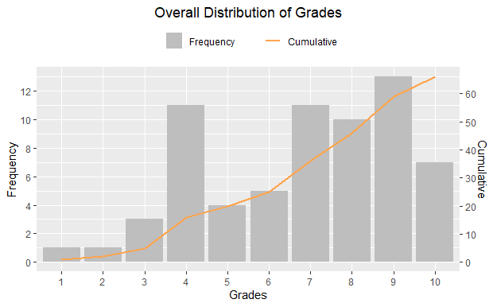

```r
ratio <- max(freq.table$Freq) / max(freq.table$Cumulative) #Create a ratio variable for the Y axis limit

freq.graph <- ggplot(freq.table, aes(x = Grade)) +
    # Create a bargraph for the absolute frequency
  geom_bar(aes(y=Freq, fill="Frequency"), size = 1, stat="identity") +
     # Create a line graph for Cumulative Count
   geom_line(aes(y = Cumulative*ratio, colour = "Cumulative"), group=1, size=1) +
    # Create labels
   labs(title = "Overall Distribution of Grades", x = "Grades", y = "Frequency" ) +
    # Scale the secondary values
   scale_y_continuous(breaks=seq(0,max(freq.table$Freq),by = 2),
                      sec.axis=sec_axis(~./ratio,name="Cumulative", breaks=seq(0,max(freq.table$Cumulative), by = 10))) +
    #Set color and legend setings
   scale_colour_manual("Cumulative", values=c("Cumulative" = "tan1"))+
   scale_fill_manual("Frequency",values="grey")+
    #Set plot design
   theme(plot.title = element_text(hjust = 0.5), #Title in the center
         #Legend layout:
         legend.key=element_blank(),
         legend.title=element_blank(),
         legend.box="horizontal",
         legend.position = "top")

freq.graph
```

```r
NA
```

#### Histogram 2 (Relative Number)

Create a proportion table for the relative values based on the freq.table

```r
prop.table <- as.data.frame(cbind(Grade = freq.table$Grade,
                                  Freq=prop.table(freq.table$Freq),
                                  Cumulative = cumsum(prop.table(freq.table$Freq))))
prop.table$Grade <- factor(prop.table$Grade, levels = c(1:10))

prop.table
```

| Grade | Freq | Cumulative |
| --- | --- | --- |
| 1 | 0.01515152 | 0.01515152 |
| 2 | 0.01515152 | 0.03030303 |
| 3 | 0.04545455 | 0.07575758 |
| 4 | 0.16666667 | 0.24242424 |
| 5 | 0.06060606 | 0.30303030 |
| 6 | 0.07575758 | 0.37878788 |
| 7 | 0.16666667 | 0.54545455 |
| 8 | 0.15151515 | 0.69696970 |
| 9 | 0.19696970 | 0.89393939 |
| 10 | 0.10606061 | 1.00000000 |

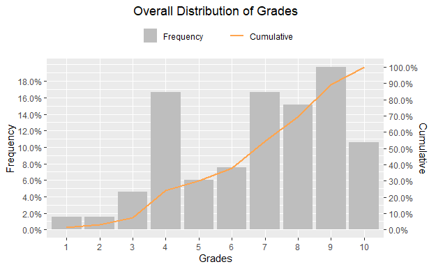

```r
ratio <- max(prop.table$Freq) / max(prop.table$Cumulative)


 relative.graph <- ggplot(prop.table, aes(x = Grade)) +
 #Create a bargraph
  geom_bar(aes(y=Freq, fill="Frequency"), size = 1, stat="identity") +
   #Create a line graph for cumulative
   geom_line(aes(y = Cumulative*ratio, colour = "Cumulative"), group=1, size=1) +
    #Add labels
   labs(title = "Overall Distribution of Grades", x = "Grades", y = "Frequency" ) +
    #Adjust grid major lines and secondary axis
   scale_y_continuous(breaks=seq(0,max(prop.table$Freq),by = 0.02),
                                 labels = scales::percent,
                                 sec.axis=sec_axis(~./ratio,name="Cumulative",
                                          breaks=seq(0,max(prop.table$Cumulative), by = 0.1), labels = scales::percent)) +
    # Add Legend and adjust legend and title positions
   scale_colour_manual("Cumulative", values=c("Cumulative" = "tan1"))+
   scale_fill_manual("Frequency",values="grey")+
   theme(plot.title = element_text(hjust = 0.5),
         legend.key=element_blank(),
         legend.title=element_blank(),
         legend.box="horizontal",
         legend.position = "top")

 relative.graph
```

### Graphics by Students

Create a table with all the calculations

```r
#Because current Stdev function in R is Stdev for Sample, we need to create a function
sd.p <- function(x){sd(x)*sqrt((length(x)-1)/length(x))}

#Create a table for everyting
stat.table <- cbind(Students = RawDF$Students,
                    Sum = rowSums(RawDF[,-1]),
                    Mean = round(rowMeans(RawDF[,-1]),2),
                    Stdev = round(apply(RawDF[,-1],1,sd.p),2),
                    Skewness = round(apply(RawDF[,-1],1,skewness,na.rm= TRUE),2),
                    Kurtosis = round(apply(RawDF[,-1],1,kurtosis,na.rm= TRUE),2)) %>% as.data.frame

#Because the results of function above showing numeric values, we need to transform them to numeric values
stat.table <- as.data.frame(cbind(Students = stat.table$Students, as.data.frame( lapply(stat.table[,-1], as.numeric))))

#Add the table for Mean of Means
stat.table <- transform(stat.table, MeanOfMeans = mean(stat.table$Mean), MeanStd = mean(stat.table$Stdev), MeanSkew = mean(stat.table$Skewness), MeanKurtosis = mean(stat.table$Kurtosis))

head(stat.table)
```

|  | Students | Sum | Mean | Stdev | Skewness | Kurtosis | MeanOfMeans | MeanStd | MeanSkew | MeanKurtosis |
| --- | --- | --- | --- | --- | --- | --- | --- | --- | --- | --- |
| 1 | a | 41 | 6.83 | 2.73 | -0.50 | -1.96 | 6.817273 | 2.031818 | -0.2272727 | -1.485455 |
| 2 | b | 43 | 7.17 | 1.46 | -1.19 | -0.41 | 6.817273 | 2.031818 | -0.2272727 | -1.485455 |
| 3 | c | 53 | 8.83 | 1.34 | -1.02 | -0.58 | 6.817273 | 2.031818 | -0.2272727 | -1.485455 |
| 4 | d | 33 | 5.50 | 2.36 | 0.00 | -1.81 | 6.817273 | 2.031818 | -0.2272727 | -1.485455 |
| 5 | e | 44 | 7.33 | 1.70 | -0.71 | -1.07 | 6.817273 | 2.031818 | -0.2272727 | -1.485455 |
| 6 | f | 36 | 6.00 | 2.52 | 0.24 | -1.89 | 6.817273 | 2.031818 | -0.2272727 | -1.485455 |

##### Means Grade by Student

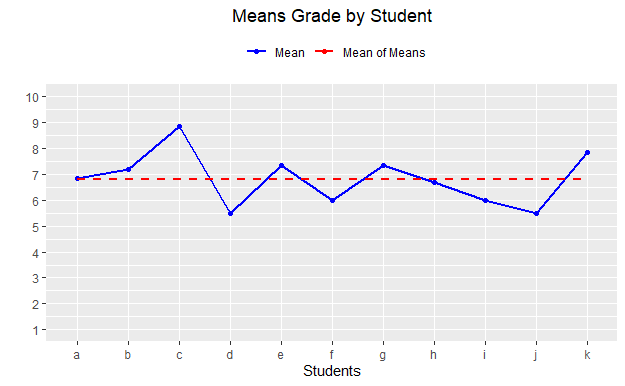

```r
#A variable for Y axes limit
y.grid <- seq(min(RawDF[,-1]), max(RawDF[,-1]), by = 1)

student.mean <- ggplot(stat.table,aes(x = Students)) +
   geom_line(aes(y = Mean, colour = "Mean"), size = 1 , group = 1) +
   geom_point(aes(y = Mean,  colour = "Mean")) +
   geom_line(aes (y = MeanOfMeans , colour = "Mean of Means"), group = 1, size = 1, linetype = "dashed") +
   scale_y_continuous(limits = c(min(RawDF[,-1]), max(RawDF[,-1])),  breaks = y.grid )+
   labs(title = "Means Grade by Student", x ="Students", y="") +
    scale_colour_manual(values=c("Mean" = "blue", "Mean of Means" = "red")) +
    theme(plot.title = element_text(hjust = 0.5),
         legend.key=element_blank(),
         legend.title=element_blank(),
         legend.box="horizontal",
         legend.position = "top")

student.mean
```

##### Standard Deviation of Grades by Student

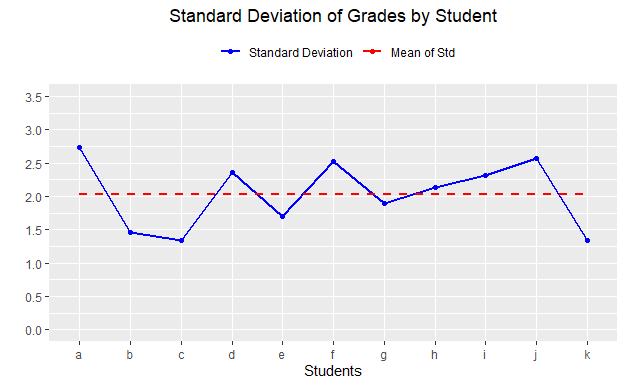

```r
student.stdev <- ggplot(stat.table,aes(x = Students)) +
   geom_line(aes(y = Stdev, colour = "Standard Deviation"), size = 1 , group = 1) +
   geom_point(aes(y = Stdev,  colour = "Standard Deviation")) +
   geom_line(aes (y = MeanStd , colour = "Mean of Std"), group = 1, size = 1, linetype = "dashed") +
   scale_y_continuous(limits = c(0,3.5),  breaks = seq(0,3.5,by =0.5))+
   labs(title = "Standard Deviation of Grades by Student", x ="Students", y="") +
   scale_colour_manual(values=c("Standard Deviation" = "blue", "Mean of Std" = "red")) +
    theme(plot.title = element_text(hjust = 0.5),
         legend.key=element_blank(),
         legend.title=element_blank(),
         legend.box="horizontal",
         legend.position = "top")
student.stdev
```

##### Skewness of Grades by Student

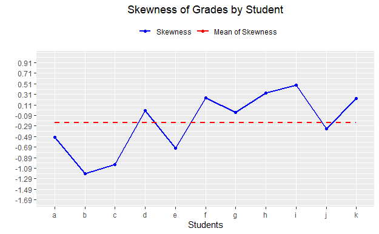

```r
student.skewness <- ggplot(stat.table,aes(x = Students)) +
   geom_line(aes(y = Skewness, colour = "Skewness"), size = 1 , group = 1) +
   geom_point(aes(y = Skewness,  colour = "Skewness")) +
   geom_line(aes (y = MeanSkew , colour = "Mean of Skewness"), group = 1, size = 1, linetype = "dashed") +
   scale_y_continuous(limits = c(min(stat.table$Skewness) - 0.5, max (stat.table$Skewness) + 0.5),  breaks = seq(min(stat.table$Skewness) - 0.5, max (stat.table$Skewness) + 0.5,by =0.2))+
   labs(title = "Skewness of Grades by Student", x ="Students", y="") +
   scale_colour_manual(values=c("Skewness" = "blue", "Mean of Skewness" = "red")) +
    theme(plot.title = element_text(hjust = 0.5),
         legend.key=element_blank(),
         legend.title=element_blank(),
         legend.box="horizontal",
         legend.position = "top")
student.skewness
```

##### Kurtosis of Grades by Student

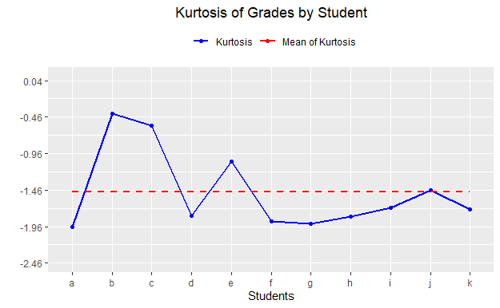

```r
student.kurtosis <- ggplot(stat.table,aes(x = Students)) +
   geom_line(aes(y = Kurtosis, colour = "Kurtosis"), size = 1 , group = 1) +
   geom_point(aes(y = Kurtosis,  colour = "Kurtosis")) +
   geom_line(aes (y = MeanKurtosis , colour = "Mean of Kurtosis"), group = 1, size = 1, linetype = "dashed") +
   scale_y_continuous(limits = c(min(stat.table$Kurtosis)-0.5, max(stat.table$Kurtosis)+0.5),  breaks = seq( min(stat.table$Kurtosis)-0.5, max(stat.table$Kurtosis)+0.5, by =0.5))+
   labs(title = "Kurtosis of Grades by Student", x ="Students", y="") +
   scale_colour_manual(values=c("Kurtosis" = "blue", "Mean of Kurtosis" = "red")) +
    theme(plot.title = element_text(hjust = 0.5),
         legend.key=element_blank(),
         legend.title=element_blank(),
         legend.box="horizontal",
         legend.position = "top")
student.kurtosis
```

### Graphics by Course

Create a transpose table for seeing the Course average

```r
courseDF <- RawDF %>% t() %>% as.data.frame()

#Change the first row as column names
colnames(courseDF) <- courseDF[1,]
courseDF <- courseDF[-1, ]

#Change row names as a new column for Course
courseDF <- tibble::rownames_to_column(courseDF, "Course")

#Change all course columns to Numeric
courseDF <- cbind("Course"= courseDF[,1], as.data.frame(lapply(courseDF[,-1], as.numeric)))
```

```r
sd.p <- function(x){sd(x)*sqrt((length(x)-1)/length(x))}

course.table <- cbind(Course = courseDF$Course,
                    Sum = rowSums(courseDF[,-1]),
                    Mean = round(rowMeans(courseDF[,-1]),2),
                    Stdev = round(apply(courseDF[,-1],1,sd.p),2),
                    Skewness = round(apply(courseDF[,-1],1,skewness,na.rm= TRUE),2),
                    Kurtosis = round(apply(courseDF[,-1],1,kurtosis,na.rm= TRUE),2)) %>% as.data.frame

course.table <- as.data.frame(cbind(Course = course.table$Course, as.data.frame( lapply(course.table[,-1], as.numeric))))

# Add Mean of Means Table
course.table <- transform(course.table, MeanOfMeans = mean(course.table$Mean), MeanStd = mean(course.table$Stdev), MeanSkew = mean(course.table$Skewness), MeanKurtosis = mean(course.table$Kurtosis))
```

##### Means Grade by Course

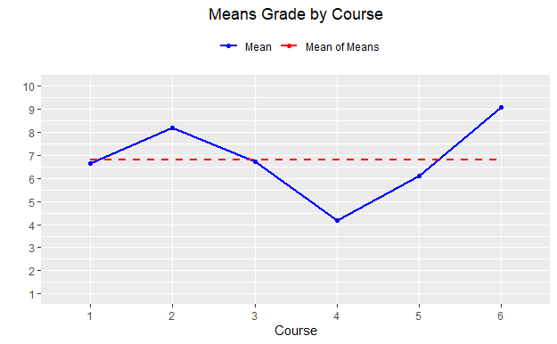

```r
y.grid <- seq(min(courseDF[,-1]), max(courseDF[,-1]), by = 1)

course.mean <- ggplot(course.table,aes(x = Course)) +
   geom_line(aes(y = Mean, colour = "Mean"), size = 1 , group = 1) +
   geom_point(aes(y = Mean,  colour = "Mean")) +
   geom_line(aes (y = MeanOfMeans , colour = "Mean of Means"), group = 1, size = 1, linetype = "dashed") +
   scale_y_continuous(limits = c(min(courseDF[,-1]), max(courseDF[,-1])),  breaks = y.grid )+
   labs(title = "Means Grade by Course", x ="Course", y="") +
    scale_colour_manual(values=c("Mean" = "blue", "Mean of Means" = "red")) +
    theme(plot.title = element_text(hjust = 0.5),
         legend.key=element_blank(),
         legend.title=element_blank(),
         legend.box="horizontal",
         legend.position = "top")
course.mean
```

##### Standard Deviation of Grades by Course

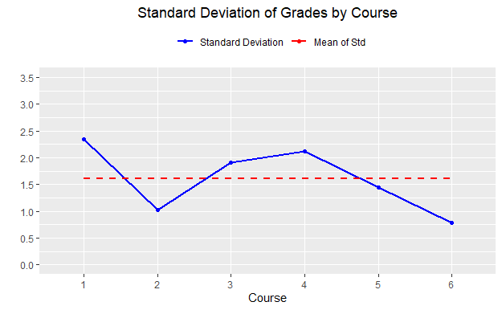

```r
course.stdev <- ggplot(course.table,aes(x = Course)) +
   geom_line(aes(y = Stdev, colour = "Standard Deviation"), size = 1 , group = 1) +
   geom_point(aes(y = Stdev,  colour = "Standard Deviation")) +
   geom_line(aes (y = MeanStd , colour = "Mean of Std"), group = 1, size = 1, linetype = "dashed") +
   scale_y_continuous(limits = c(0,3.5),  breaks = seq(0,3.5,by =0.5))+
   labs(title = "Standard Deviation of Grades by Course", x ="Course", y="") +
   scale_colour_manual(values=c("Standard Deviation" = "blue", "Mean of Std" = "red")) +
    theme(plot.title = element_text(hjust = 0.5),
         legend.key=element_blank(),
         legend.title=element_blank(),
         legend.box="horizontal",
         legend.position = "top")
course.stdev
```

##### Skewness of Grades by Course

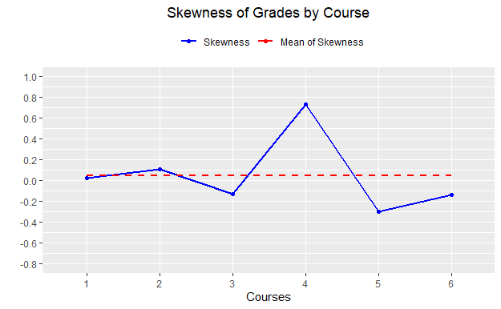

```r
course.skewness <- ggplot(course.table,aes(x = Course)) +
   geom_line(aes(y = Skewness, colour = "Skewness"), size = 1 , group = 1) +
   geom_point(aes(y = Skewness,  colour = "Skewness")) +
   geom_line(aes (y = MeanSkew , colour = "Mean of Skewness"), group = 1, size = 1, linetype = "dashed") +
   scale_y_continuous(limits = c(min(course.table$Skewness) - 0.5, max (stat.table$Skewness) + 0.5),  breaks = seq(min(course.table$Skewness) - 0.5, max (course.table$Skewness) + 0.5,by =0.2))+
   labs(title = "Skewness of Grades by Course", x ="Courses", y="") +
   scale_colour_manual(values=c("Skewness" = "blue", "Mean of Skewness" = "red")) +
    theme(plot.title = element_text(hjust = 0.5),
         legend.key=element_blank(),
         legend.title=element_blank(),
         legend.box="horizontal",
         legend.position = "top")
course.skewness
```

##### Kurtosis of Grades by Course

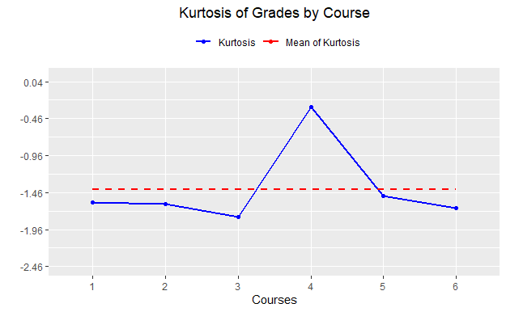

```r
course.kurtosis <- ggplot(course.table,aes(x = Course)) +
   geom_line(aes(y = Kurtosis, colour = "Kurtosis"), size = 1 , group = 1) +
   geom_point(aes(y = Kurtosis,  colour = "Kurtosis")) +
   geom_line(aes (y = MeanKurtosis , colour = "Mean of Kurtosis"), group = 1, size = 1, linetype = "dashed") +
   scale_y_continuous(limits = c(min(stat.table$Kurtosis)-0.5, max(stat.table$Kurtosis)+0.5),  breaks = seq(min(stat.table$Kurtosis)-0.5, max(stat.table$Kurtosis)+0.5, by =0.5))+
   labs(title = "Kurtosis of Grades by Course", x ="Courses", y="") +
   scale_colour_manual(values=c("Kurtosis" = "blue", "Mean of Kurtosis" = "red")) +
    theme(plot.title = element_text(hjust = 0.5),
         legend.key=element_blank(),
         legend.title=element_blank(),
         legend.box="horizontal",
         legend.position = "top")
course.kurtosis
```

## Summary

```r
#Print HTML table
complete.table
```

| Students | 1 | 2 | 3 | 4 | 5 | 6 | Histogram | Sparkline |
| --- | --- | --- | --- | --- | --- | --- | --- | --- |
| a | 3 | 9 | 9 | 3 | 8 | 9 | {"x":{"values":[3,9,9,3,8,9],"options":{"type":"bar","chartRangeMin":100,"chartRangeMax":9,"height":20,"width":60},"width":60,"height":20},"evals":[],"jsHooks":[]} | {"x":{"values":[3,9,9,3,8,9],"options":{"type":"line","chartRangeMin":100,"chartRangeMax":9,"height":20,"width":60},"width":60,"height":20},"evals":[],"jsHooks":[]} |
| b | 8 | 8 | 7 | 4 | 8 | 8 | {"x":{"values":[8,8,7,4,8,8],"options":{"type":"bar","chartRangeMin":100,"chartRangeMax":8,"height":20,"width":60},"width":60,"height":20},"evals":[],"jsHooks":[]} | {"x":{"values":[8,8,7,4,8,8],"options":{"type":"line","chartRangeMin":100,"chartRangeMax":8,"height":20,"width":60},"width":60,"height":20},"evals":[],"jsHooks":[]} |
| c | 9 | 10 | 9 | 9 | 6 | 10 | {"x":{"values":[9,10,9,9,6,10],"options":{"type":"bar","chartRangeMin":100,"chartRangeMax":10,"height":20,"width":60},"width":60,"height":20},"evals":[],"jsHooks":[]} | {"x":{"values":[9,10,9,9,6,10],"options":{"type":"line","chartRangeMin":100,"chartRangeMax":10,"height":20,"width":60},"width":60,"height":20},"evals":[],"jsHooks":[]} |
| d | 4 | 7 | 4 | 2 | 7 | 9 | {"x":{"values":[4,7,4,2,7,9],"options":{"type":"bar","chartRangeMin":100,"chartRangeMax":9,"height":20,"width":60},"width":60,"height":20},"evals":[],"jsHooks":[]} | {"x":{"values":[4,7,4,2,7,9],"options":{"type":"line","chartRangeMin":100,"chartRangeMax":9,"height":20,"width":60},"width":60,"height":20},"evals":[],"jsHooks":[]} |
| e | 7 | 9 | 8 | 4 | 7 | 9 | {"x":{"values":[7,9,8,4,7,9],"options":{"type":"bar","chartRangeMin":100,"chartRangeMax":9,"height":20,"width":60},"width":60,"height":20},"evals":[],"jsHooks":[]} | {"x":{"values":[7,9,8,4,7,9],"options":{"type":"line","chartRangeMin":100,"chartRangeMax":9,"height":20,"width":60},"width":60,"height":20},"evals":[],"jsHooks":[]} |
| f | 10 | 7 | 4 | 3 | 4 | 8 | {"x":{"values":[10,7,4,3,4,8],"options":{"type":"bar","chartRangeMin":100,"chartRangeMax":10,"height":20,"width":60},"width":60,"height":20},"evals":[],"jsHooks":[]} | {"x":{"values":[10,7,4,3,4,8],"options":{"type":"line","chartRangeMin":100,"chartRangeMax":10,"height":20,"width":60},"width":60,"height":20},"evals":[],"jsHooks":[]} |
| g | 5 | 9 | 8 | 5 | 7 | 10 | {"x":{"values":[5,9,8,5,7,10],"options":{"type":"bar","chartRangeMin":100,"chartRangeMax":10,"height":20,"width":60},"width":60,"height":20},"evals":[],"jsHooks":[]} | {"x":{"values":[5,9,8,5,7,10],"options":{"type":"line","chartRangeMin":100,"chartRangeMax":10,"height":20,"width":60},"width":60,"height":20},"evals":[],"jsHooks":[]} |
| h | 6 | 9 | 5 | 4 | 6 | 10 | {"x":{"values":[6,9,5,4,6,10],"options":{"type":"bar","chartRangeMin":100,"chartRangeMax":10,"height":20,"width":60},"width":60,"height":20},"evals":[],"jsHooks":[]} | {"x":{"values":[6,9,5,4,6,10],"options":{"type":"line","chartRangeMin":100,"chartRangeMax":10,"height":20,"width":60},"width":60,"height":20},"evals":[],"jsHooks":[]} |
| i | 4 | 8 | 6 | 4 | 4 | 10 | {"x":{"values":[4,8,6,4,4,10],"options":{"type":"bar","chartRangeMin":100,"chartRangeMax":10,"height":20,"width":60},"width":60,"height":20},"evals":[],"jsHooks":[]} | {"x":{"values":[4,8,6,4,4,10],"options":{"type":"line","chartRangeMin":100,"chartRangeMax":10,"height":20,"width":60},"width":60,"height":20},"evals":[],"jsHooks":[]} |
| j | 7 | 7 | 5 | 1 | 4 | 9 | {"x":{"values":[7,7,5,1,4,9],"options":{"type":"bar","chartRangeMin":100,"chartRangeMax":9,"height":20,"width":60},"width":60,"height":20},"evals":[],"jsHooks":[]} | {"x":{"values":[7,7,5,1,4,9],"options":{"type":"line","chartRangeMin":100,"chartRangeMax":9,"height":20,"width":60},"width":60,"height":20},"evals":[],"jsHooks":[]} |

[output cut: 3 more lines]

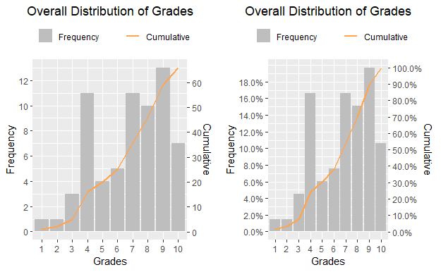

```r
#Print Dstribution Graphs
ggarrange(freq.graph, relative.graph, nrow=1, ncol=2)
```

The graph is showing the distribution of grades in numbers. The line value is showing the cumulative count of grades, which is equel to 66 (11 students, 6 course = 66 grades)

The graph is showing the distribution of grades in percentile. The line value is showing the cumulative count of grades in percentile.

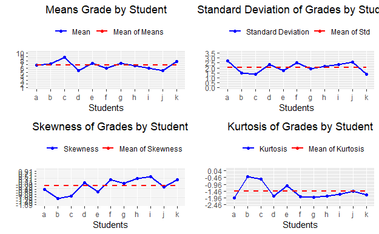

```r
#Summary of all Students Graphs
ggarrange(student.mean, student.stdev, student.skewness,student.kurtosis)
```

Means grade by student Blue line shows the mean of student grades. Red line shows the mean of mean. Student C perform the highest and the student D & J performed the lowest. Standard deviation of grades by student Blue line shows the standard deviation of student grades.Red line shows the mean of students. Student C & K has lowest standard deviations and the student A has the highest. Skewness of Grades by student Blue line shows the skewness of student grades. Red line shows the mean of skewness. Mean of skewness is below 0. Kurtosis of grades by student Blue line shows the kurtosis of student grades. Red line shows the mean of kurtosis. Mean of kurtosis is below 0.

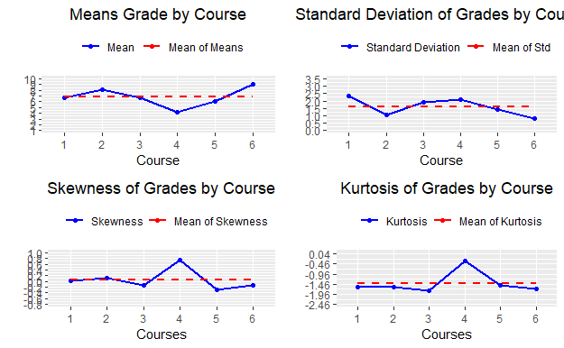

```r
#Summary of all Courses Graphs
ggarrange(course.mean, course.stdev, course.skewness,course.kurtosis)
```

Means grade by course Blue line shows the mean grade of courses. Red line shows the mean of mean. course 6 perform the highest and the course 4 performed the lowest. Standard deviation of grades by course Blue line shows the standard deviation of courses. Red line shows the mean of student. course 6 has the lowest standard deviation and the course 1 has the highest. Skewness of Grades by course Blue line shows the skewness of courses. Red line shows the mean of skewness. course 4 has the highest skewness and the course 5 has the lowest. Kurtosis of grades by course Blue line shows the kurtosis of courses. Red line shows the mean of kurtosis. course 4 has the highest kurtosis and the course 3 has the lowest.